# Analyze_ab_test_results_notebook

## Analyze A/B Test Results

- Introduction
- Part I - Probability
- Part II - A/B Test
- Part III - Regression

#### Part I - Probability

```python
# import libraries
import pandas as pd
import numpy as np
import random
import matplotlib.pyplot as plt
%matplotlib inline
#We are setting the seed to assure you get the same answers on quizzes as we set up
random.seed(42)
```

```python
df = pd.read_csv('ab_data.csv')
df.head()
```

|  | user_id | timestamp | group | landing_page | converted |
| --- | --- | --- | --- | --- | --- |
| 0 | 851104 | 2017-01-21 22:11:48.556739 | control | old_page | 0 |
| 1 | 804228 | 2017-01-12 08:01:45.159739 | control | old_page | 0 |
| 2 | 661590 | 2017-01-11 16:55:06.154213 | treatment | new_page | 0 |
| 3 | 853541 | 2017-01-08 18:28:03.143765 | treatment | new_page | 0 |
| 4 | 864975 | 2017-01-21 01:52:26.210827 | control | old_page | 1 |

Shape of dataset:

```python
df.shape
```

```
(294478, 5)
```

Number of unique users:

```python
df['user_id'].nunique()
```

```
290584
```

The proportion of users converted:

```python
df['converted'].mean()
```

```
0.11965919355605512
```

The number of times the `new_page` and `treatment` don't match:

```python
df[(df['group'] == 'control') & (df['landing_page'] == 'new_page')].shape[0] + df[(df['group']=='treatment') & (df['landing_page']=='old_page')].shape[0]
```

```
3893
```

```python
# any missing values?
df.info()
```

```
<class 'pandas.core.frame.DataFrame'>
RangeIndex: 294478 entries, 0 to 294477
Data columns (total 5 columns):
user_id         294478 non-null int64
timestamp       294478 non-null object
group           294478 non-null object
landing_page    294478 non-null object
converted       294478 non-null int64
dtypes: int64(2), object(3)
memory usage: 11.2+ MB
```

For the rows where **treatment** does not match with **new_page** or **control** does not match with **old_page**, we can't be sure if this row truly received the new or old page. Dropping these rows.

```python
df2 = df.drop(df[(df['group'] == 'control') & (df['landing_page'] == 'new_page')].index)
df2 = df2.drop(df[(df['group']=='treatment') & (df['landing_page']=='old_page')].index)
df2.shape
```

```
(290585, 5)
```

```python
# everything dropped properly?
df2[((df2['group'] == 'treatment') == (df2['landing_page'] == 'new_page')) == False].shape[0]
```

```
0
```

```python
# Check for duplicated IDs
df2['dupes'] =df2['user_id'].duplicated(keep=False)
df2.query('dupes == True')
```

|  | user_id | timestamp | group | landing_page | converted | dupes |
| --- | --- | --- | --- | --- | --- | --- |
| 1899 | 773192 | 2017-01-09 05:37:58.781806 | treatment | new_page | 0 | True |
| 2893 | 773192 | 2017-01-14 02:55:59.590927 | treatment | new_page | 0 | True |

```python
# drop the one dupe
df2.drop([2893], inplace=True)
```

```python
df2.head()
```

|  | user_id | timestamp | group | landing_page | converted | dupes |
| --- | --- | --- | --- | --- | --- | --- |
| 0 | 851104 | 2017-01-21 22:11:48.556739 | control | old_page | 0 | False |
| 1 | 804228 | 2017-01-12 08:01:45.159739 | control | old_page | 0 | False |
| 2 | 661590 | 2017-01-11 16:55:06.154213 | treatment | new_page | 0 | False |
| 3 | 853541 | 2017-01-08 18:28:03.143765 | treatment | new_page | 0 | False |
| 4 | 864975 | 2017-01-21 01:52:26.210827 | control | old_page | 1 | False |

Average conversion rate?

```python
df2['converted'].mean()
```

```
0.11959708724499628
```

Given that an individual was in the `control` group, what is the probability they converted?

```python
df2.query('group == "control"')['converted'].mean()
```

```
0.1203863045004612
```

Given that an individual was in the `treatment` group, what is the probability they converted?

```python
df2.query('group == "treatment"')['converted'].mean()
```

```
0.11880806551510564
```

What is the probability that an individual received the new page?

```python
df2.query('landing_page == "new_page"').shape[0] / df2.shape[0]
```

```
0.5000619442226688
```

How long did the study run?

```python
df['timestamp'].min(), df['timestamp'].max()
```

```
('2017-01-02 13:42:05.378582', '2017-01-24 13:41:54.460509')
```

Any obvious difference in conversions?

```python
obs_diff = df2.query('group == "treatment"')['converted'].mean() - df2.query('group == "control"')['converted'].mean()
obs_diff
```

```
-0.0015782389853555567
```

**Based on this, I don't think there's sufficient evidence that the new treatment page leads to either more conversions. Perhaps it's just a case of needing more time, as this experiment lasted less than a month.**

### Part II - A/B Test

Assuming that the old page was better than the new, and a type I error rate of 5%, these are my null and alternative hypotheses:

H0: **$p_{new}$** - **$p_{old}$** <= 0

H1: **$p_{new}$** - **$p_{old}$** > 0

More assumptions: under the null hypothesis, $p_{new}$ and $p_{old}$ both have "true" success rates equal to the **converted** success rate regardless of page-- i.e. $p_{new}$ and $p_{old}$ are equal. Also assuming they are equal to the **converted** rate in **ab_data.csv** regardless of the page.

```python
# calculate null standard deviation under assumptions listed above
nullsd = np.std(df2['converted'])
```

**Conversion rate** for $p_{new}$ under the null:

```python
pnew = df2.converted.mean()
pnew
```

```
0.11959708724499628
```

**Conversion rate** for $p_{old}$ under the null (same as null, given assumptions):

```python
pold = df2.converted.mean()
```

Calculate $n_{new}$ (the number of individuals in the treatment group):

```python
nnew = df2.query('group == "treatment"').shape[0]
nnew
```

```
145310
```

Calculate $n_{old}$ (the number of individuals in the control group):

```python
nold =df2.query('group == "control"').shape[0]
nold
```

```
145274
```

Now I'll simulate $n_{new}$ transactions with a conversion rate of $p_{new}$ under the null. I'll use a sample size for each page equal to the ones in **ab_data.csv**.

```python
# store simulated occurences in new_page_converted
new_page_converted = np.random.choice([0,1], size=nnew, p=(pnew, 1-pnew))
```

Simulate $n_{old}$ transactions with a conversion rate of $p_{old}$ under the null.

```python
# store in old_page_converted
old_page_converted = np.random.choice([0,1], size = nold, p=(pold, 1-pold))
```

Find $p_{new}$ - $p_{old}$ for the simulated values:

```python
new_page_converted.mean() - old_page_converted.mean()
```

```
-0.001174859789793592
```

Now I'll create 10,000 $p_{new}$ - $p_{old}$ values using the same simulation process from before:

```python
new_page_converted = np.random.binomial(nnew, pnew, 10000)/nnew
old_page_converted = np.random.binomial(nold, pold, 10000)/nnew
p_diffs = new_page_converted-old_page_converted
```

Plot a histogram of the **p_diffs**. Does this plot look like what you expected?

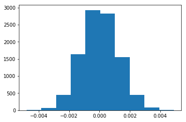

```python
# plot histogram of p_diffs. Everything look normal?
plt.hist(p_diffs);
```

**This is about what I expected. The observed difference falls inside the sample distribution, meaning it's quite likely to be observed under the null hypothesis. According to this, it appears we can't reject the null.**

```python
p_diffs = np.array(p_diffs)
```

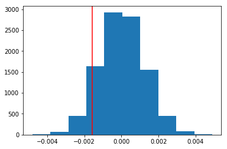

```python
plt.hist(p_diffs);
plt.axvline(obs_diff, c = 'red');
```

Calculate the p-value (proportion of the **p_diffs** that are greater than the actual difference observed in **ab_data.csv**):

```python
(p_diffs > obs_diff).mean()
```

```
0.91120000000000001
```

**By computing the p-value we got the probability, when the null hypothesis is true, that we will observe a statistic (difference in mean, in this case) in favor of the alternative hypothesis. P-values essentially tell us whether or not the observed difference from the sample reflects a true difference between populations.**

**A small p-value (we're looking for < 5% here) would confirm that our observed statistic isn't well supported under the null hypothesis, and that we should reject it. Thus, a large p-value, like the one we got in this case (90%) tells us that our data is well-supported under the null hypothesis. In other words, we fail to reject the null.**

Next I'll use a built-in to do the same thing I did above in a tenth of the time:

```python
import statsmodels.api as sm

convert_old = df2[df2['group']=='control']['converted'].sum()
convert_new = df2[df2['group']=='treatment']['converted'].sum()
n_old = df2[df2['group']=='control'].shape[0]
n_new = df2[df2['group']=='treatment'].shape[0]
```

```python
# get z-score and p-value using stats models' proportions_ztest
z_score, p_value = sm.stats.proportions_ztest([convert_new, convert_old], [n_new, n_old], alternative='larger')
z_score, p_value
```

```
(-1.3109241984234394, 0.90505831275902449)
```

**The z-score tells us a bit about the variability of our data. The z-score needed in order to reject the null hypothesis is called the critical value, which is dependent on the significance level (alpha). The negative z-score that was computed here tells us our statistic is 1.3 standard deviations below the mean. For a one-sided test with alpha at .05, the critical value needed would be 1.65. Since 1.3 falls inside that range, we should fail to reject the null.**

**As for the p-value, it is almost exactly what we observed in our test above (90%). This high p-value also tells us that we do not have sufficient evidence to reject the null.**

**Thus, the built-in method leads us to the same conclusion as the manual method performed above. Both result in a failure to reject the null.**

### Part III - A regression approach

`1.` In this final part, you will see that the result you achieved in the A/B test in Part II above can also be achieved by performing regression.

a. Since each row is either a conversion or no conversion, what type of regression should you be performing in this case?

**Logistic regression**

In this section I'll use logistic regression to fit a model that will tell us if there's a significant difference in conversion based on which page a customer receives.

```python
# add intercept column (=1) and a dummy variable for which landing page the user gets (1=treatment, 0=control)
df2['intercept'] =1
df2[['ab_page','old_page']] = pd.get_dummies(df2['landing_page'])
df2 = df2.drop('old_page', 1)
df2.head()
```

|  | user_id | timestamp | group | landing_page | converted | dupes | intercept | ab_page |
| --- | --- | --- | --- | --- | --- | --- | --- | --- |
| 0 | 851104 | 2017-01-21 22:11:48.556739 | control | old_page | 0 | False | 1 | 0 |
| 1 | 804228 | 2017-01-12 08:01:45.159739 | control | old_page | 0 | False | 1 | 0 |
| 2 | 661590 | 2017-01-11 16:55:06.154213 | treatment | new_page | 0 | False | 1 | 1 |
| 3 | 853541 | 2017-01-08 18:28:03.143765 | treatment | new_page | 0 | False | 1 | 1 |
| 4 | 864975 | 2017-01-21 01:52:26.210827 | control | old_page | 1 | False | 1 | 0 |

c. Use **statsmodels** to instantiate your regression model on the two columns you created in part b., then fit the model using the two columns you created in part **b.** to predict whether or not an individual converts.

```python
# use statsmodels to create appropriate model, then fit the model with logmod.fit()
logmod = sm.Logit(df2['converted'], df2[['intercept', 'ab_page']]);
res = logmod.fit();
```

```
Optimization terminated successfully.
         Current function value: 0.366118
         Iterations 6
```

```python
# show model summary
res.summary()
```

Logit Regression Results

| Dep. Variable: | converted | No. Observations: | 290584 |
| --- | --- | --- | --- |
| Model: | Logit | Df Residuals: | 290582 |
| Method: | MLE | Df Model: | 1 |
| Date: | Sat, 01 Jun 2019 | Pseudo R-squ.: | 8.077e-06 |
| Time: | 12:54:43 | Log-Likelihood: | -1.0639e+05 |
| converged: | True | LL-Null: | -1.0639e+05 |
|  |  | LLR p-value: | 0.1899 |

|  | coef | std err | z | P>\|z\| | [0.025 | 0.975] |
| --- | --- | --- | --- | --- | --- | --- |
| intercept | -1.9888 | 0.008 | -246.669 | 0.000 | -2.005 | -1.973 |
| ab_page | -0.0150 | 0.011 | -1.311 | 0.190 | -0.037 | 0.007 |

**The p-value associated with ab_page is .190, rendering it insignificant. However, the p-value here is different from what we observed in Part II. This is because the hypotheses underlying the two methods are different: the first was a one-tailed test, and the other was two-tailed. In Part II, our null and alternative hypotheses were set up as such:**

*H0: Pnew - Pold <= 0*

*H1: Pnew - Pold > 0*

**In Part III we are running a logistic regression on our data to determine the strenght of the linear relationship between our dependent (conversion rate) and independent variables (landing page), which we get from the slope. Ergo, we have a two-tailed hypothesis that looks like this:**

*H0: B1 = 0*

*H1: B1 != 0*

**Since we are comparing whether there is any difference (not > or < than), we know this is a two-tailed test that will take into consideration both ends of the sampling distribution. This accounts for the difference between the two methods.**

**That being said, it'd be a good idea to consider adding other factors into our regression model. This will make it more robust, and will likely lead to more accurate predictions. More information typically leads to better informed results. There are disadvantages to this, of course. More variables means more complexity, making it harder to interpret the model summary. The possibility of overfitting our model is also present. Overfitting, or modeling the training set too tightly, prevents the model from making accurate predictions on any new data (ungeneralizable), effectively rendering it useless.**

```python
# add another variable (country) and see if conversion rate is affected
countries = pd.read_csv('countries.csv')
```

```python
df2 = df2.merge(countries, on='user_id', how='inner')
df2.head()
```

|  | user_id | timestamp | group | landing_page | converted | dupes | intercept | ab_page | country |
| --- | --- | --- | --- | --- | --- | --- | --- | --- | --- |
| 0 | 851104 | 2017-01-21 22:11:48.556739 | control | old_page | 0 | False | 1 | 0 | US |
| 1 | 804228 | 2017-01-12 08:01:45.159739 | control | old_page | 0 | False | 1 | 0 | US |
| 2 | 661590 | 2017-01-11 16:55:06.154213 | treatment | new_page | 0 | False | 1 | 1 | US |
| 3 | 853541 | 2017-01-08 18:28:03.143765 | treatment | new_page | 0 | False | 1 | 1 | US |
| 4 | 864975 | 2017-01-21 01:52:26.210827 | control | old_page | 1 | False | 1 | 0 | US |

```python
df2[['CA', 'UK', 'US']] = pd.get_dummies(df2['country'])
```

```python
logmod2 = sm.Logit(df2['converted'], df2[['intercept','US', 'UK', 'ab_page']])
res2 = logmod2.fit()
res2.summary()
```

```
Optimization terminated successfully.
         Current function value: 0.366113
         Iterations 6
```

Logit Regression Results

| Dep. Variable: | converted | No. Observations: | 290584 |
| --- | --- | --- | --- |
| Model: | Logit | Df Residuals: | 290580 |
| Method: | MLE | Df Model: | 3 |
| Date: | Sat, 01 Jun 2019 | Pseudo R-squ.: | 2.323e-05 |
| Time: | 12:54:45 | Log-Likelihood: | -1.0639e+05 |
| converged: | True | LL-Null: | -1.0639e+05 |
|  |  | LLR p-value: | 0.1760 |

|  | coef | std err | z | P>\|z\| | [0.025 | 0.975] |
| --- | --- | --- | --- | --- | --- | --- |
| intercept | -2.0300 | 0.027 | -76.249 | 0.000 | -2.082 | -1.978 |
| US | 0.0408 | 0.027 | 1.516 | 0.130 | -0.012 | 0.093 |
| UK | 0.0506 | 0.028 | 1.784 | 0.074 | -0.005 | 0.106 |
| ab_page | -0.0149 | 0.011 | -1.307 | 0.191 | -0.037 | 0.007 |

```python
np.exp(.0408), np.exp(.0506), 1/np.exp(-.0149)
```

```
(1.0416437559600236, 1.0519020483004984, 1.0150115583846535)
```

**According to these results (with Canada as the baseline), we can see that users in the US are about 1.04 times as likely to convert, and UK users are 1.05 times as likely. Since the p-values for both variables are too high, we can't take this difference to mean anything significant.**

#### I'm now going to look at an *interaction* between page and country to see if there are significant effects on conversion.

```python
df2['page_UK'] = df2['UK']*df2['ab_page']
df2['page_US'] = df2['US']*df2['ab_page']
df2['page_CA'] = df2['CA']*df2['ab_page']
```

```python
logmod3 = sm.Logit(df2['converted'], df2[['intercept', 'ab_page', 'page_UK', 'page_US', 'UK', 'US']])
res3= logmod3.fit()
res3.summary()
```

```
Optimization terminated successfully.
         Current function value: 0.366109
         Iterations 6
```

Logit Regression Results

| Dep. Variable: | converted | No. Observations: | 290584 |
| --- | --- | --- | --- |
| Model: | Logit | Df Residuals: | 290578 |
| Method: | MLE | Df Model: | 5 |
| Date: | Sat, 23 Mar 2019 | Pseudo R-squ.: | 3.482e-05 |
| Time: | 15:14:56 | Log-Likelihood: | -1.0639e+05 |
| converged: | True | LL-Null: | -1.0639e+05 |
|  |  | LLR p-value: | 0.1920 |

|  | coef | std err | z | P>\|z\| | [0.025 | 0.975] |
| --- | --- | --- | --- | --- | --- | --- |
| intercept | -2.0040 | 0.036 | -55.008 | 0.000 | -2.075 | -1.933 |
| ab_page | -0.0674 | 0.052 | -1.297 | 0.195 | -0.169 | 0.034 |
| page_UK | 0.0783 | 0.057 | 1.378 | 0.168 | -0.033 | 0.190 |
| page_US | 0.0469 | 0.054 | 0.872 | 0.383 | -0.059 | 0.152 |
| UK | 0.0118 | 0.040 | 0.296 | 0.767 | -0.066 | 0.090 |
| US | 0.0175 | 0.038 | 0.465 | 0.642 | -0.056 | 0.091 |

**This shows there is no significant relationship between conversion rate and country, or landing page, or even of a combination country and landing page. The conversion rate here is largely unaffected by any and all of these variables, thus we can feel comfortable failing to reject the null.**

For the hell of it, I'll add time to this equation and see if there's any added influence on conversion.

```python
from datetime import datetime
```

```python
for col in df2:
    print (type(df2[col][1]))
```

```
<class 'numpy.int64'>
<class 'str'>
<class 'str'>
<class 'str'>
<class 'numpy.int64'>
<class 'numpy.bool_'>
<class 'numpy.int64'>
<class 'numpy.uint8'>
<class 'str'>
<class 'numpy.uint8'>
<class 'numpy.uint8'>
<class 'numpy.uint8'>
<class 'numpy.uint8'>
<class 'numpy.uint8'>
<class 'numpy.uint8'>
```

```python
df2['timestamp'] = pd.to_datetime(df2['timestamp'], format = '%Y-%m-%d %H:%M:%S.%f')
```

```python
df2['timestamp'].dtype
```

```
dtype('<M8[ns]')
```

```python
times = df2.iloc[:,1]

time = pd.DataFrame({"month": times.dt.month,
              "day": times.dt.day,
              "hour": times.dt.hour,
              "week": times.dt.week,
              "weekday": times.dt.weekday
             })
```

```python
time['weekend'] = np.where(time['weekday'] < 5, 0, 1)
time.head()
```

|  | month | day | hour | week | weekday | weekend |
| --- | --- | --- | --- | --- | --- | --- |
| 0 | 1 | 21 | 22 | 3 | 5 | 1 |
| 1 | 1 | 12 | 8 | 2 | 3 | 0 |
| 2 | 1 | 11 | 16 | 2 | 2 | 0 |
| 3 | 1 | 8 | 18 | 1 | 6 | 1 |
| 4 | 1 | 21 | 1 | 3 | 5 | 1 |

```python
df3 = df2.join(time)
```

```python
df3[['week1', 'week2', 'week3', 'week4']] = pd.get_dummies(df3['week'])
df3.head()
```

|  | user_id | timestamp | group | landing_page | converted | dupes | intercept | ab_page | country | CA | ... | month | day | hour | week | weekday | weekend | week1 | week2 | week3 | week4 |
| --- | --- | --- | --- | --- | --- | --- | --- | --- | --- | --- | --- | --- | --- | --- | --- | --- | --- | --- | --- | --- | --- |
| 0 | 851104 | 2017-01-21 22:11:48.556739 | control | old_page | 0 | False | 1 | 0 | US | 0 | ... | 1 | 21 | 22 | 3 | 5 | 1 | 0 | 0 | 1 | 0 |
| 1 | 804228 | 2017-01-12 08:01:45.159739 | control | old_page | 0 | False | 1 | 0 | US | 0 | ... | 1 | 12 | 8 | 2 | 3 | 0 | 0 | 1 | 0 | 0 |
| 2 | 661590 | 2017-01-11 16:55:06.154213 | treatment | new_page | 0 | False | 1 | 1 | US | 0 | ... | 1 | 11 | 16 | 2 | 2 | 0 | 0 | 1 | 0 | 0 |
| 3 | 853541 | 2017-01-08 18:28:03.143765 | treatment | new_page | 0 | False | 1 | 1 | US | 0 | ... | 1 | 8 | 18 | 1 | 6 | 1 | 1 | 0 | 0 | 0 |
| 4 | 864975 | 2017-01-21 01:52:26.210827 | control | old_page | 1 | False | 1 | 0 | US | 0 | ... | 1 | 21 | 1 | 3 | 5 | 1 | 0 | 0 | 1 | 0 |

5 rows × 25 columns

```python
logmod4 = sm.Logit(df3['converted'], df3[['intercept', 'ab_page', 'US', 'UK', 'weekend', 'week2', 'week3', 'week4']])
res4 = logmod4.fit()
res4.summary()
```

```
Optimization terminated successfully.
         Current function value: 0.366107
         Iterations 6
```

Logit Regression Results

| Dep. Variable: | converted | No. Observations: | 290584 |
| --- | --- | --- | --- |
| Model: | Logit | Df Residuals: | 290576 |
| Method: | MLE | Df Model: | 7 |
| Date: | Sat, 23 Mar 2019 | Pseudo R-squ.: | 4.030e-05 |
| Time: | 15:14:57 | Log-Likelihood: | -1.0638e+05 |
| converged: | True | LL-Null: | -1.0639e+05 |
|  |  | LLR p-value: | 0.2846 |

|  | coef | std err | z | P>\|z\| | [0.025 | 0.975] |
| --- | --- | --- | --- | --- | --- | --- |
| intercept | -2.0402 | 0.028 | -71.894 | 0.000 | -2.096 | -1.985 |
| ab_page | -0.0149 | 0.011 | -1.303 | 0.193 | -0.037 | 0.008 |
| US | 0.0406 | 0.027 | 1.511 | 0.131 | -0.012 | 0.093 |
| UK | 0.0506 | 0.028 | 1.784 | 0.074 | -0.005 | 0.106 |
| weekend | 0.0035 | 0.013 | 0.266 | 0.790 | -0.022 | 0.029 |
| week2 | 0.0019 | 0.015 | 0.128 | 0.898 | -0.027 | 0.031 |
| week3 | 0.0196 | 0.015 | 1.338 | 0.181 | -0.009 | 0.048 |
| week4 | 0.0339 | 0.024 | 1.409 | 0.159 | -0.013 | 0.081 |

It doesn't appear that adding variables like weekend or week # of the study contributed at all to our understanding of the data.

## Resources

> For help converting the timestamp variables, I consulted this awesome blog: http://hamelg.blogspot.com/2015/11/python-for-data-analysis-part-17.html

> I also use stack overflow regularly to help with inane questions.

```python
from subprocess import call
call(['python', '-m', 'nbconvert', 'Analyze_ab_test_results_notebook.ipynb'])
```

```
0
```